# BayeScan results

J. Ignacio Lucas Lledó

10/5/2020

```r
knitr::opts_chunk$set(echo = TRUE)
library(ggplot2)
```

# Introduction

BayeScan (Foll and Gaggiotti 2008) attempts to identify loci under diverging or balancing selection among species, using allele frequencies. It assumes an island model, where two or more subpopulations share a pool of migrants that maintain allele frequencies correlated. It can also be applied to a fission model, where two or more populations derive from a common ancestral one. It is based on a logistic regression of $F_{ij}$ (the “probability that two randomly chosen chromosomes in a population have a common ancestor in that population, without there having been any intervening migration or mutation”) on the locus $i$ and the population $j$ (Beaumont and Balding 2004):

$\log\left( \frac{F_{ij}}{1 - F_{ij}} \right) = \alpha_i + \beta_j$

It uses a Bayesian approach to estimate the posterior distribution of $\alpha_i$, the parameters that represent the locus-specific effects on $F_{ij}$, such as natural selection. $F_{ij}$ are also estimated. The prior makes most loci have $\alpha_i = 0$. When $\alpha_i > 0$, the locus has higher $F_{ij}$ values than expected. That is, the locus is under diversifying selection. If $\alpha_i < 0$, it could mean the locus is very conserved (under negative selection) if minor allele frequency is low; or it could mean balancing selection, if allele frequencies are not low.

# Comparison between Kristyna’s a my results

Kristýna was inspired by Barbora’s use of BayeScan to Czechoslovakian wolfdogs and their parent dog population, German shepherds (Caniglia et al. 2018). Admixed hedgehog individuals are not the same as a hybrid population. But when comparing admixed individuals to either parental species, I understand that common introgressed loci would be $F_{ST}$ outliers, expected to have positive and significant $\alpha_i$ values. On the other side, if introgressed loci are not correlated among admixed individuals, the high $F_{ST}$ values likely caused by introgression could be attributed to a genome-wide, population effect. Especially if the admixed fraction of the genome is high.

```r
params$KEA
```

```
## [1] "/data/kristyna/hedgehog/results_2020/2020-04-13/europaeus_admixed_bayescan10_fst.txt"
```

```r
KEA <- read.table(params$KEA, header=TRUE, colClasses='numeric')
colnames(KEA) <- paste0('K.', colnames(KEA))
KRA <- read.table(params$KRA, header=TRUE, colClasses='numeric')
colnames(KRA) <- paste0('K.', colnames(KRA))
#KERA <- read.table(params$KERA, header=TRUE, colClasses='numeric')
#colnames(KERA) <- paste0('K.', colnames(KERA))
IEA <- read.table(params$IEA, header=TRUE, colClasses='numeric')
colnames(IEA) <- paste0('I.', colnames(IEA))
IRA <- read.table(params$IRA, header=TRUE, colClasses='numeric')
colnames(IRA) <- paste0('I.', colnames(IRA))
# IERA <- read.table(params$IERA, header=TRUE, colClasses='numeric')
# colnames(IERA) <- paste0('I.', colnames(IERA))
stopifnot(all.equal(dim(KEA), dim(IEA)), all.equal(dim(KRA), dim(IRA)))

EA <- cbind(KEA, IEA)
RA <- cbind(KRA, IRA)

loci <- read.table('loci.txt', col.names = c('chr','pos'), header=FALSE)
EA <- cbind(EA, loci)
RA <- cbind(RA, loci)

p1 <- ggplot(EA, aes(x=I.alpha, y=K.alpha)) + geom_point() +
  ggtitle('E. europaeus vs. admixed') + xlab('Alpha estimate by Ignasi') +
  ylab('Alpha estimate by Kristyna')
p2 <- ggplot(RA, aes(x=I.alpha, y=K.alpha)) + geom_point() +
  ggtitle('E. roumanicus vs. admixed') + xlab('Alpha estimate by Ignasi') +
  ylab('Alpha estimate by Kristyna')

EA$alpha.diff <- EA$K.alpha - EA$I.alpha
RA$alpha.diff <- RA$K.alpha - RA$I.alpha

p3 <- ggplot(EA, aes(x=alpha.diff)) + geom_histogram() +
  ggtitle('E. europaeus vs. admixed') + xlab('Difference in estimates of Alpha')
p4 <- ggplot(RA, aes(x=alpha.diff)) + geom_histogram() +
  ggtitle('E. roumanicus vs admixed') + xlab('Difference in estimates of Alpha')
```

[output not shown]

# Reproduction and interpretation of plots

The `plot_R.r` file includes the function `plot_bayescan()`, which I copy below (it’s under GNU General Public License, Copyright (C) 2010 Matthieu Foll).

```r
plot_bayescan<-function(res,FDR=0.05,size=1,pos=0.35,highlight=NULL,name_highlighted=F,add_text=T){
  if (is.character(res))
    res=read.table(res)

  colfstat=5
  colq=colfstat-2

  highlight_rows=which(is.element(as.numeric(row.names(res)),highlight))
  non_highlight_rows=setdiff(1:nrow(res),highlight_rows)

  outliers=as.integer(row.names(res[res[,colq]<=FDR,]))

  ok_outliers=TRUE
  if (sum(res[,colq]<=FDR)==0)
    ok_outliers=FALSE;

  res[res[,colq]<=0.0001,colq]=0.0001

  # plot
  plot(log10(res[,colq]),res[,colfstat],xlim=rev(range(log10(res[,colq]))),xlab="log10(q value)",ylab=names(res[colfstat]),type="n")
  points(log10(res[non_highlight_rows,colq]),res[non_highlight_rows,colfstat],pch=19,cex=size)

  if (name_highlighted) {
        if (length(highlight_rows)>0) {
                text(log10(res[highlight_rows,colq]),res[highlight_rows,colfstat],row.names(res[highlight_rows,]),col="red",cex=size*1.2,font=2)
        }
  } else {
        points(log10(res[highlight_rows,colq]),res[highlight_rows,colfstat],col="red",pch=19,cex=size)
        # add names of loci over p and vertical line
        if (ok_outliers & add_text) {
                text(log10(res[res[,colq]<=FDR,][,colq])+pos*(round(runif(nrow(res[res[,colq]<=FDR,]),1,2))*2-3),res[res[,colq]<=FDR,][,colfstat],row.names(res[res[,colq]<=FDR,]),cex=size)
        }
  }
  lines(c(log10(FDR),log10(FDR)),c(-1,1),lwd=2)

  return(list("outliers"=outliers,"nb_outliers"=length(outliers)))
}
```

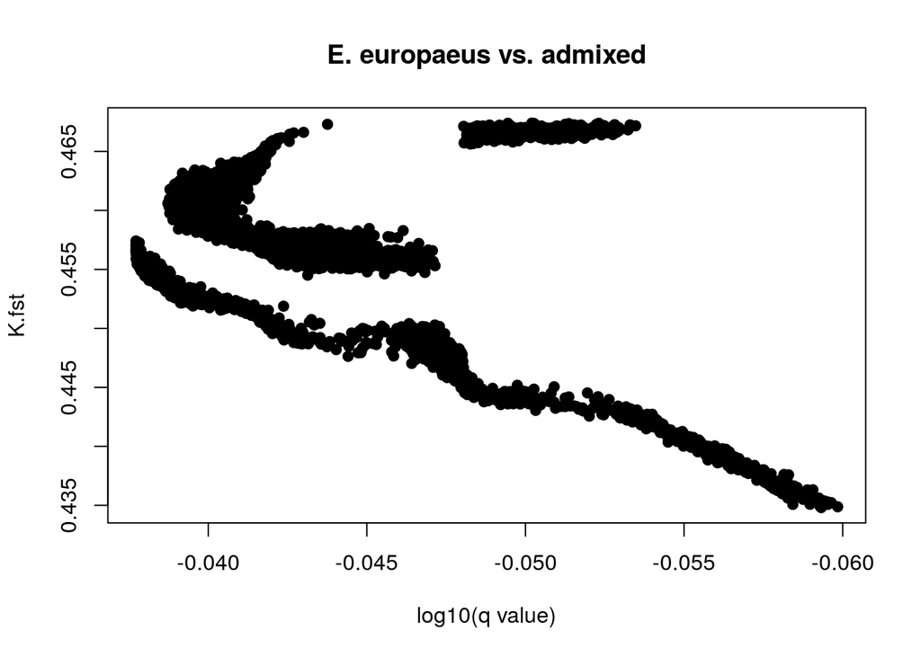

```r
ea <- plot_bayescan(EA)
title('E. europaeus vs. admixed')
```

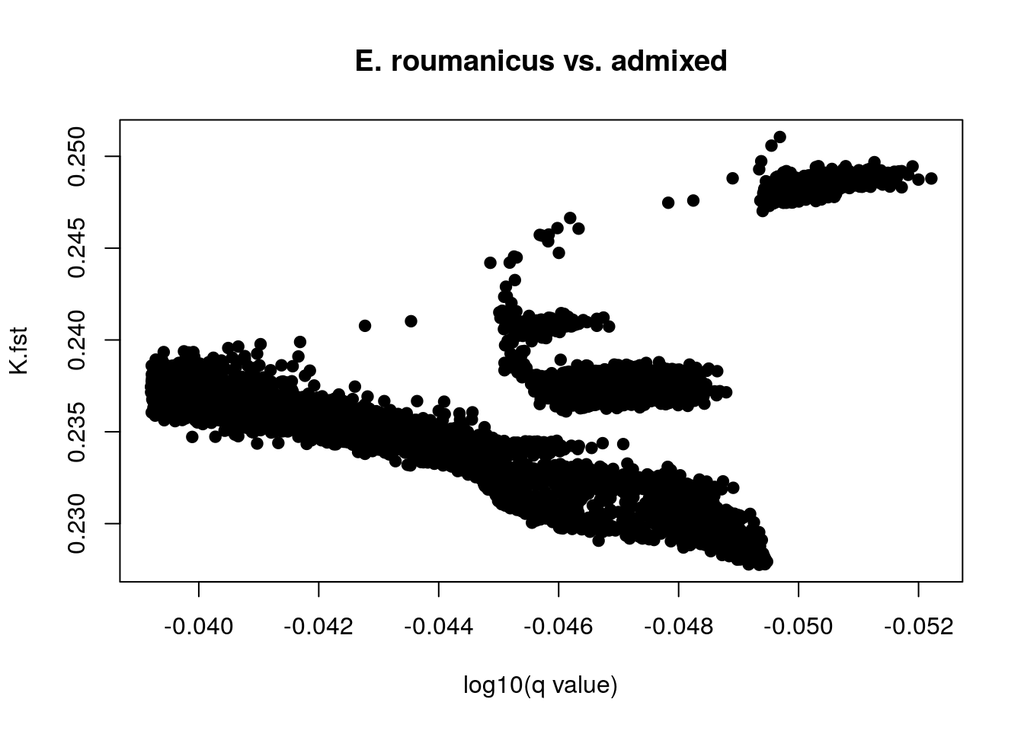

```r
ra <- plot_bayescan(RA)
title('E. roumanicus vs. admixed')
```

There are 0 outlier loci in the comparison between *E. europaeus* and the admixed *population*. And there are 0 outlier loci in the comparison between *E. roumanicus* and the admixed individuals. In the plots above it is important to notice that the horizontal axis is reversed: values to the right are lower q-values. None reach significance. The points branch off in two directions that correspond with two classes of loci: under diverging (high $F_{ST}$) or balancing (low $F_{ST}$) selection. If we plotted $\alpha_i$ estimates, instead of $F_{ST}$, the plots would have the same shape, because that is the average $F_{ST}$ between populations, which masks the population specific $\beta_j$ components and becomes very much correlated with $\alpha_i$.

$F_{ST}$ values are higher between *E. europaeus* and the admixed individuals than between *E. roumanicus* and the admixed individuals.

# Advanced plots

Kristyna found another script to plot results from Bayescan. It is called `Bayescan_advanced_plots.R`. It seems to come from [Laura Benestan](https://github.com/laurabenestan/Bayescan/wiki) github page. Below, I simplify the code to produce equivalent plots, skipping the writing of lists of SNPs to text files. Thus, I don’t need SNP names. I realize the original script labels as *balancing* all SNPs with a negative $\alpha_i$, irrespectively of their q value. That is, even if those negative $\alpha_i$ are not significantly different from zero. That error in the script can make it look as if there were loci under balancing selection, but it does not need be the case.

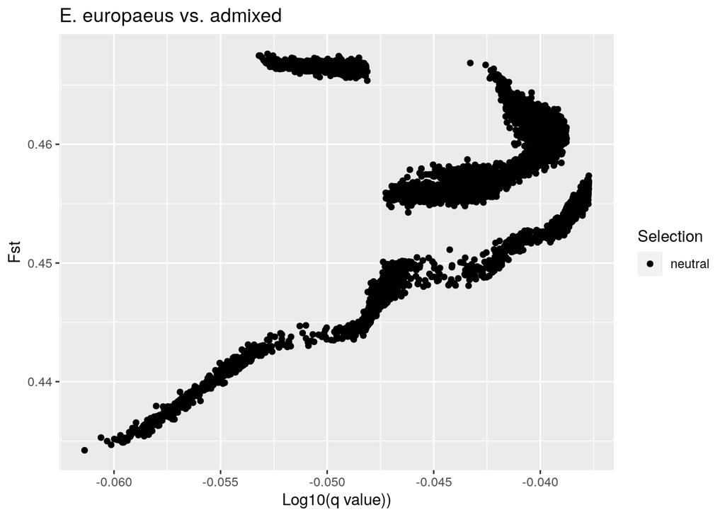

```r
EA$I.selection <- factor('neutral', levels=c('balancing','neutral','diversifying'))
RA$I.selection <- factor('neutral', levels=c('balancing','neutral','diversifying'))
EA[EA$I.qval < 0.05 & EA$I.alpha > 0, 'selection'] <- 'diversifying'
RA[RA$I.qval < 0.05 & RA$I.alpha > 0, 'selection'] <- 'diversifying'
EA[EA$I.qval < 0.05 & EA$I.alpha < 0, 'selection'] <- 'balancing'
RA[RA$I.qval < 0.05 & RA$I.alpha < 0, 'selection'] <- 'balancing'

# We do not have qval == 0.
EA$I.log10q <- log10(EA$I.qval)
RA$I.log10q <- log10(RA$I.qval)

ggplot(EA, aes(x=I.log10q, y=I.fst, colour=I.selection)) +
  geom_point() + scale_colour_manual(name='Selection', values=c('black','red','white')) +
  ggtitle('E. europaeus vs. admixed') + xlab('Log10(q value))') + ylab('Fst')
```

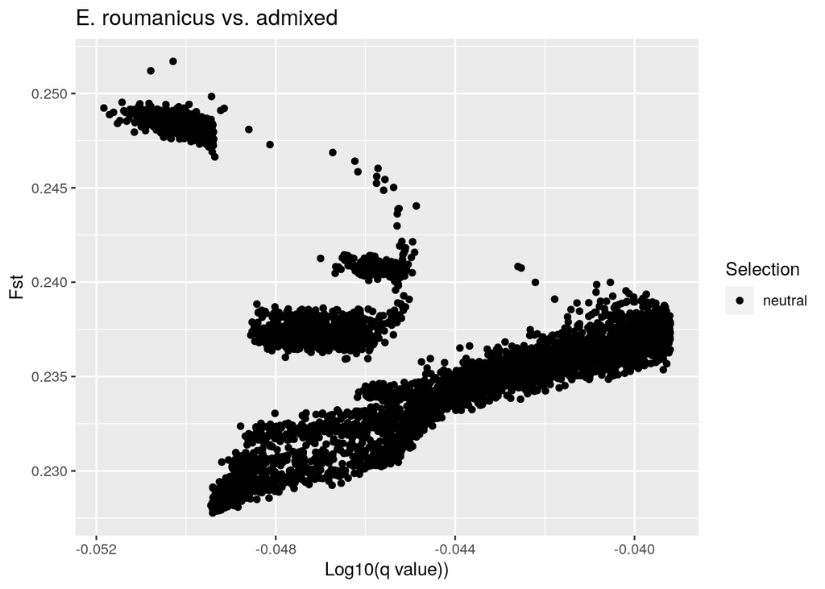

```r
ggplot(RA, aes(x=I.log10q, y=I.fst, colour=I.selection)) +
  geom_point() + scale_colour_manual(name='Selection', values=c('black','red','white')) +
  ggtitle('E. roumanicus vs. admixed') + xlab('Log10(q value))') + ylab('Fst')
```

So, the additional plot produced with the `Bayescan_advanced_plot.R` script does not provide any additional information, mostly because we do not have significant loci.

# References

Beaumont, Mark A., and David J. Balding. 2004. “Identifying Adaptive Genetic Divergence Among Populations from Genome Scans.” *Molecular Ecology* 13: 969–80. https://doi.org/10.1111/j.1365-294X.2004.02125.x.

Caniglia, R., E. Fabbri, P. Hulva, B. Černá Bolfíková, M. Jindřichová, A. Vik Stronen, I Dykyy, et al. 2018. “Wolf Outside, Dog Inside? The Genomic Make-up of the Czechoslovakian Wolfdog.” *BMC Genomics*, no. 19: 533. https://doi.org/10.1186/s12864-018-4916-2.

Foll, Matthieu, and Oscar Gaggiotti. 2008. “A Genome-Scan Method to Identify Selected Loci Appropriate for Both Dominant and Codominant Markers: A Bayesian Perspective.” *Genetics* 180 (2): 977–93. https://doi.org/10.1534/genetics.108.092221.